# Minería de datos: mod01

# 4 Ejercicios

## 4.1 Ejercicio 1:

Estudia los tres casos siguientes y contesta, de forma razonada la pregunta que se realiza:

- Disponemos de un conjunto de variables referentes a vehículos, tales como la marca, modelo, año de matriculación, etc. También se dispone del precio al que se vendieron. Al poner a la venta a un nuevo vehículo, se dispone de las variables que lo describen, pero se desconoce el precio. ¿Qué tipo de algoritmo se debería aplicar para predecir de forma automática el precio?
- En un almacén de naranjas se tiene una máquina, que de forma automática obtiene un conjunto de variables de cada naranja, como su tamaño, acidez, grado maduración, etc. Si se desea estudiar las naranjas por tipos, según las variables obtenidas, ¿qué tipo de algoritmo es el más adecuado?
- Un servicio de música por internet dispone de los historiales de audición de sus clientes: Qué canciones y qué grupos eligen los clientes a lo largo del tiempo de sus escuchas. La empresa desea crear un sistema que proponga la siguiente canción y grupo en función de la canción que se ha escuchado antes. ¿Qué tipo de algoritmo es el más adecuado?

### 4.1.1 Respuesta 1:

No termino de entender si quieres que investiguemos acerca de algoritmos de predicción o lo que haríamos. 1.1.- En el primer caso referente a los vehículos, estudiaría primero la variable del precio de compra inicial para ver si tengo NA. Si no tuviera, estudiaría la relación con el resto de variables, para ver la relación con el modelo, el año de matriculación, la marca, etc. Luego buscaría información acerca de la pérdida de valor de un coche con el paso del tiempo, el kilometraje, etc. Y a partir de ahí crearía una nueva variable con el precio de venta relacionada con los datos anteriormente objetinos. Si la variable precio de compra inicial tuviera NA primero comprobaría si tengo datos duplicados con el resto de variables que sí tengan el precio de compra. Si no fuera el caso, revisaría por modelos coches similares para estimar el precio de compra.

## 4.2 Ejercicio 2:

A partir del conjunto de datos disponible en el siguiente enlace http://archive.ics.uci.edu/ml/datasets/Adult , realiza un estudio tomando como propuesta inicial al que se ha realizado con el conjunto de datos “Titanic”. Amplia la propuesta generando nuevos indicadores o solucionando otros problemas expuestos en el módulo 2. Explica el proceso que has seguido, qué conocimiento obtienes de los datos, qué objetivo te has fijado y detalla los pasos, técnicas usadas y los problemas resueltos.

Nota: Si lo deseas puedes utilizar otro conjunto de datos propio o de algun repositorio open data siempre que sea similar en diversidad de tipos de variables al propuesto.

### 4.2.1 Respuesta 2:

```r
# Cargamos el juego de datos
datosAdult <- read.csv('http://archive.ics.uci.edu/ml/machine-learning-databases/adult/adult.data',stringsAsFactors = FALSE, header = FALSE)

# Nombres de los atributos
names(datosAdult) <- c("age","workclass","fnlwgt","education","education-num","marital-status","occupation","relationship","race","sex","capital-gain","capital-loss","hour-per-week","native-country","income")
```

```r
# Redacta aquí el código R para el estudio del juego de datos Adult
# Primero voy a comprobar la estructura de datos de Adult.
str(datosAdult)
```

```
## 'data.frame':    32561 obs. of  15 variables:
##  $ age           : int  39 50 38 53 28 37 49 52 31 42 ...
##  $ workclass     : chr  " State-gov" " Self-emp-not-inc" " Private" " Private" ...
##  $ fnlwgt        : int  77516 83311 215646 234721 338409 284582 160187 209642 45781 159449 ...
##  $ education     : chr  " Bachelors" " Bachelors" " HS-grad" " 11th" ...
##  $ education-num : int  13 13 9 7 13 14 5 9 14 13 ...
##  $ marital-status: chr  " Never-married" " Married-civ-spouse" " Divorced" " Married-civ-spouse" ...
##  $ occupation    : chr  " Adm-clerical" " Exec-managerial" " Handlers-cleaners" " Handlers-cleaners" ...
##  $ relationship  : chr  " Not-in-family" " Husband" " Not-in-family" " Husband" ...
##  $ race          : chr  " White" " White" " White" " Black" ...
##  $ sex           : chr  " Male" " Male" " Male" " Male" ...
##  $ capital-gain  : int  2174 0 0 0 0 0 0 0 14084 5178 ...
##  $ capital-loss  : int  0 0 0 0 0 0 0 0 0 0 ...
##  $ hour-per-week : int  40 13 40 40 40 40 16 45 50 40 ...
##  $ native-country: chr  " United-States" " United-States" " United-States" " United-States" ...
##  $ income        : chr  " <=50K" " <=50K" " <=50K" " <=50K" ...
```

Tenemos 15 variables y 32561 observaciones.

Comprobamos si hay datos NA.

```r
any(is.na(datosAdult))
```

```
## [1] FALSE
```

No tenemos datos vacíos en nuestras variables.

Vemos las primeras filas de datosAdult.

```r
head(datosAdult)
```

```
##   age         workclass fnlwgt  education education-num
## 1  39         State-gov  77516  Bachelors            13
## 2  50  Self-emp-not-inc  83311  Bachelors            13
## 3  38           Private 215646    HS-grad             9
## 4  53           Private 234721       11th             7
## 5  28           Private 338409  Bachelors            13
## 6  37           Private 284582    Masters            14
##        marital-status         occupation   relationship   race     sex
## 1       Never-married       Adm-clerical  Not-in-family  White    Male
## 2  Married-civ-spouse    Exec-managerial        Husband  White    Male
## 3            Divorced  Handlers-cleaners  Not-in-family  White    Male
## 4  Married-civ-spouse  Handlers-cleaners        Husband  Black    Male
## 5  Married-civ-spouse     Prof-specialty           Wife  Black  Female
## 6  Married-civ-spouse    Exec-managerial           Wife  White  Female
##   capital-gain capital-loss hour-per-week native-country income
## 1         2174            0            40  United-States  <=50K
## 2            0            0            13  United-States  <=50K
## 3            0            0            40  United-States  <=50K
## 4            0            0            40  United-States  <=50K
## 5            0            0            40           Cuba  <=50K
## 6            0            0            40  United-States  <=50K
```

Vamos a analizar variable por variable.

### 4.2.2 Age

```r
unique(datosAdult$age)
```

```
##  [1] 39 50 38 53 28 37 49 52 31 42 30 23 32 40 34 25 43 54 35 59 56 19 20
## [24] 45 22 48 21 24 57 44 41 29 18 47 46 36 79 27 67 33 76 17 55 61 70 64
## [47] 71 68 66 51 58 26 60 90 75 65 77 62 63 80 72 74 69 73 81 78 88 82 83
## [70] 84 85 86 87
```

```r
summary(datosAdult$age)
```

```
##    Min. 1st Qu.  Median    Mean 3rd Qu.    Max.
##   17.00   28.00   37.00   38.58   48.00   90.00
```

La edad mínima son 17 años y la máxima 90, con una edad media de 38 años.

### 4.2.3 Workclass

```r
unique(datosAdult$workclass)
```

```
## [1] " State-gov"        " Self-emp-not-inc" " Private"
## [4] " Federal-gov"      " Local-gov"        " ?"
## [7] " Self-emp-inc"     " Without-pay"      " Never-worked"
```

Antes hemos visto que no hay valores NA pero sí que vemos que en Workclass hay valores desconocidos “?”. Calculamos la tabla de frecuencias.

```r
table(datosAdult$workclass)
```

```
##
##                 ?       Federal-gov         Local-gov      Never-worked
##              1836               960              2093                 7
##           Private      Self-emp-inc  Self-emp-not-inc         State-gov
##             22696              1116              2541              1298
##       Without-pay
##                14
```

Hay 1836 valores desconocidos. Vamos a categorizar la variable unificando el tipo de empleo por gente que trabaja para el gobierno, autónomos, sector privado y vamos a unificar la gente que nunca ha trabajado con la que no cobra y los desconocidos.

```r
self_emp <- c(" Self-emp-inc", " Self-emp-not-inc")
no_work <- c(" Never-worked", " Without-pay", " ?")
gobierno <- c(" Federal-gov", " Local-gov", " State-gov")
```

Y creamos una función para categorizarla:

```r
trabajos <- function(trabajo){
  if(trabajo %in% self_emp){
    return("self_emp")
  }else if(trabajo %in% no_work){
    return("no_work")
  }else if(trabajo %in% gobierno){
    return("gobierno")
  } else{
    return(trabajo)
  }
}
```

E incluimos las categorías en la variable:

```r
datosAdult$workclass<- sapply(datosAdult$workclass, trabajos)
```

```r
unique(datosAdult$workclass)
```

```
## [1] "gobierno" "self_emp" " Private" "no_work"
```

Vamos a ver la relación entre la edad y el tipo de trabajo.

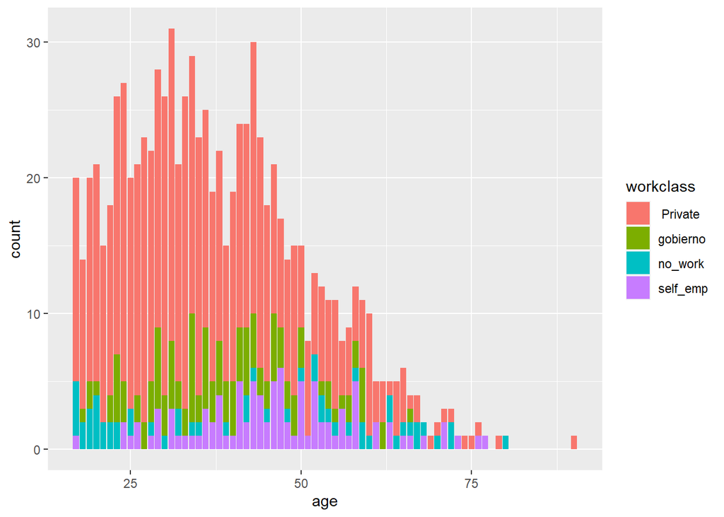

```r
ggplot(data=datosAdult[1:filas,],aes(x=age,fill=workclass))+geom_bar()
```

Vamos a ver ahora la matriz de porcentajes de frecuencias de Age y Workclass.

```r
t<-table(datosAdult[1:filas,]$age,datosAdult[1:filas,]$workclass)
for (i in 1:dim(t)[1]){
    t[i,]<-round(t[i,]/sum(t[i,])*100,2)
}
t
```

```
##
##       Private gobierno no_work self_emp
##   17    75.00     0.00   20.00     5.00
##   18    78.57     7.14   14.29     0.00
##   19    75.00    10.00   15.00     0.00
##   20    76.19     4.76   19.05     0.00
##   21    86.67     0.00   13.33     0.00
##   22    77.78    11.11   11.11     0.00
##   23    73.08    19.23    7.69     0.00
##   24    81.48    11.11    0.00     7.41
##   25    85.00     0.00   10.00     5.00
##   26    80.95     9.52    0.00     9.52
##   27    91.30     8.70    0.00     0.00
##   28    77.27    13.64    4.55     4.55
##   29    67.86    21.43    0.00    10.71
```

[output cut: 51 more lines]

### 4.2.4 fnlgt

Esta variable es el final weght, es decir, el número de personas que el censo estima que representa. Esta variable sería interesante a la hora de ver el peso real de una observación.

```r
summary(datosAdult$fnlwgt)
```

```
##    Min. 1st Qu.  Median    Mean 3rd Qu.    Max.
##   12285  117827  178356  189778  237051 1484705
```

Vemos que la media representación es de 189.778 pero que el mínimo es 12.285 y el máximo 1.484.705, por lo que hay observaciones cuyo peso es muy superior al de otras.

También vemos que la mediana es 178.356, que el Q1 es 117.827 y el Q3 237.051. El rango intercuantílico es 119.224. Teniendo en cuenta que un valor atípico extremo es aquel que dista 3 veces el rango intercuantílico por debajo de Q1 o por encima de Q3; es decir, aquel que esté por debajo o por encima de Q1 y Q3 respectivamente en 357.672.

Vamos a verlo visualmente.

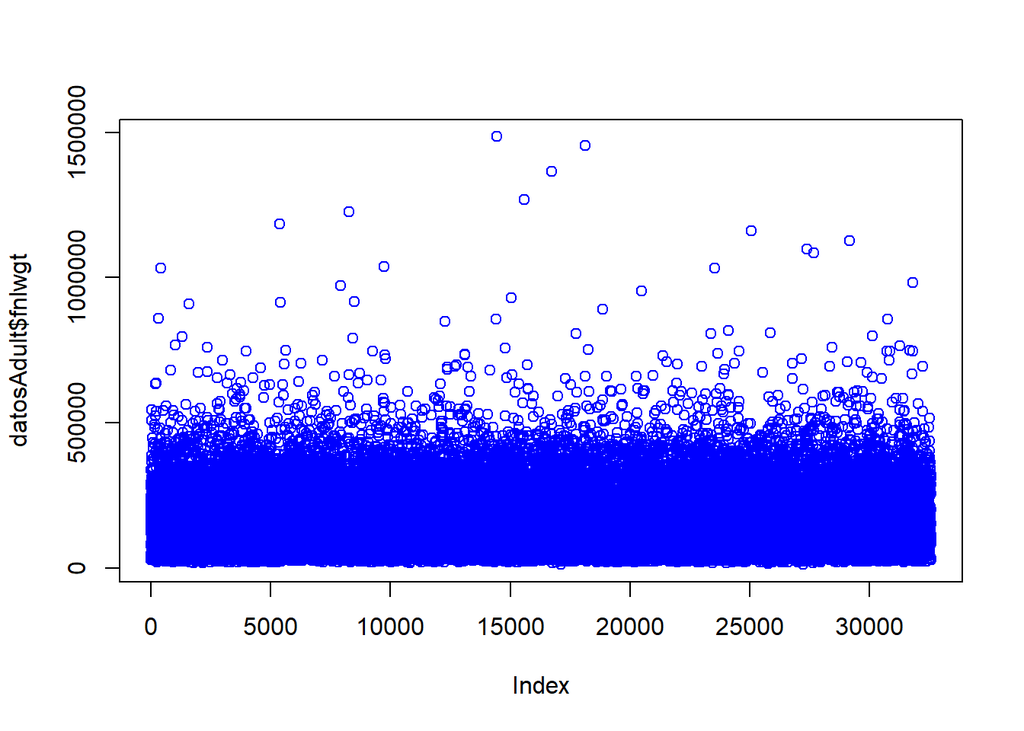

```r
plot(x= datosAdult$fnlwgt, col ="blue")
```

Con el gráfico vemos que hay outliers por arriba. Por abajo no porque sería una cifra negativa y nuestro umbral mínimo es 0.

Vamos a ver también una caja de bigotes:

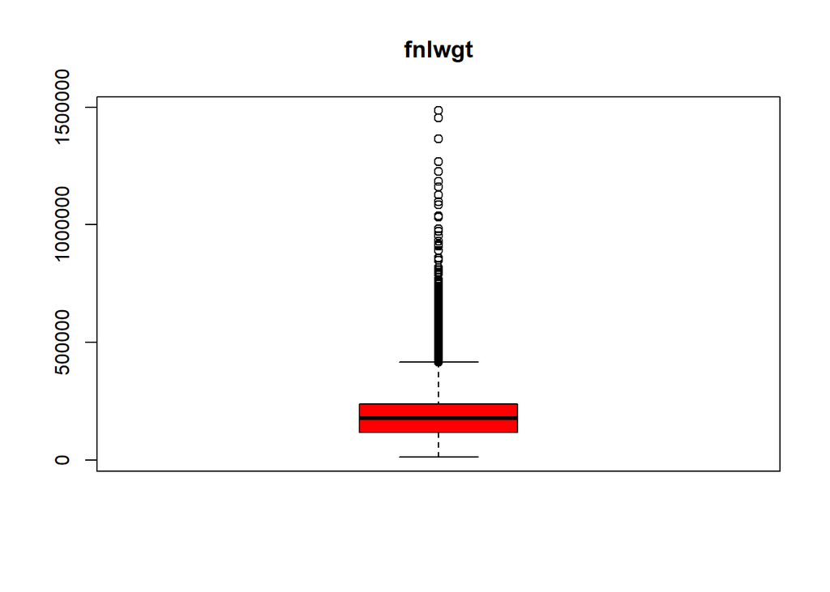

```r
boxplot(datosAdult$fnlwgt,
        main = "fnlwgt",
        boxwex = 0.5, col = "red")
```

Calculamos por aquí el rango intercuantílico:

```r
RIC= quantile(datosAdult$fnlwgt, prob=c(0.25, 0.75))
RIC
```

```
##    25%    75%
## 117827 237051
```

```r
Valor_outliers = (quantile(datosAdult$fnlwgt, prob=c(0.75)) - quantile(datosAdult$fnlwgt, prob=c(0.25))) * 3
Valor_outliers
```

```
##    75%
## 357672
```

Con lo cual vamos a ver cuántos son esos los valores por encima de esa cantidad de la variable ya que nos desvirtúan el estudio y vemos si podemos eliminarlos o los reemplazamos. Para ello creamos un df1 filtrando los datos que no serían outliers de fnlwgt.

```r
df1 <- filter(datosAdult, fnlwgt < "357672")
```

Y vemos la variable fnlwgt en nuestro dataframe filtrado gráficamente.

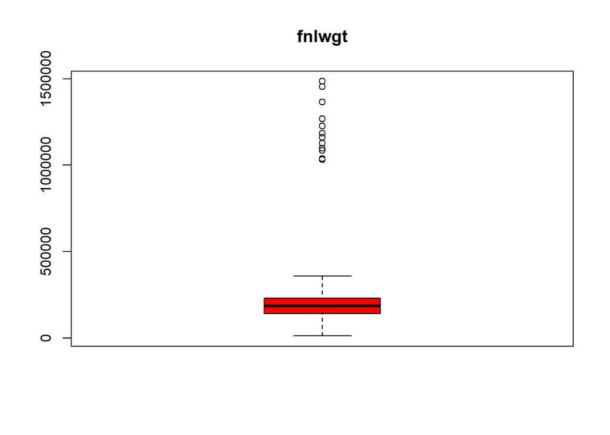

```r
boxplot(df1$fnlwgt,
        main = "fnlwgt",
        boxwex = 0.5, col = "red")
```

### 4.2.5 Marital-status

Vamos a categorizar ahora la variable marital- status.

```r
table(df1$`marital-status`)
```

```
##
##               Divorced      Married-AF-spouse     Married-civ-spouse
##                   3572                     16                  11985
##  Married-spouse-absent          Never-married              Separated
##                    335                   8448                    861
##                Widowed
##                    806
```

```r
casado <- c(" Married-AF-spouse", " Married-civ-spouse", "Married-spouse-absent")
no.casado <- c(" Divorced", " Separated", " Widowed")
nunca.casado <- c(" Never-married")
```

Mediante una función cambiamos las categorías.

```r
estado.civil <- function(estado){
  if(estado %in% casado){
    return("casado")
  }else if(estado %in% no.casado){
    return("no.casado")
  }else{
    return("nunca.casado")
  }
}
```

```r
df1$`marital-status`<- sapply(df1$`marital-status`, estado.civil)
```

Comprobamos de nuevo la variable.

```r
table(df1$`marital-status`)
```

```
##
##       casado    no.casado nunca.casado
##        12001         5239         8783
```

Vamos a verla gráficamente con edad.

```r
unique(df1$`marital-status`)
```

```
## [1] "no.casado"    "casado"       "nunca.casado"
```

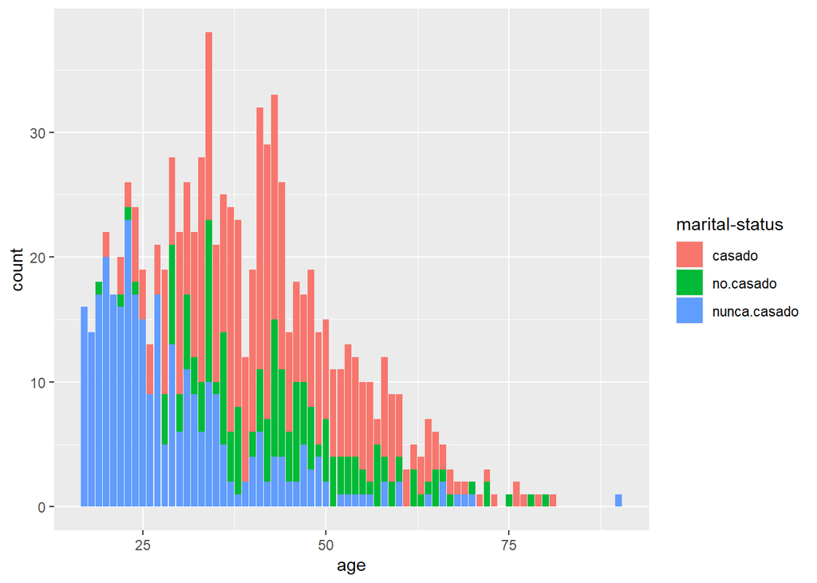

```r
ggplot(data=df1[1:filas,],aes(x=age,fill=`marital-status`))+geom_bar()
```

Y por sexo:

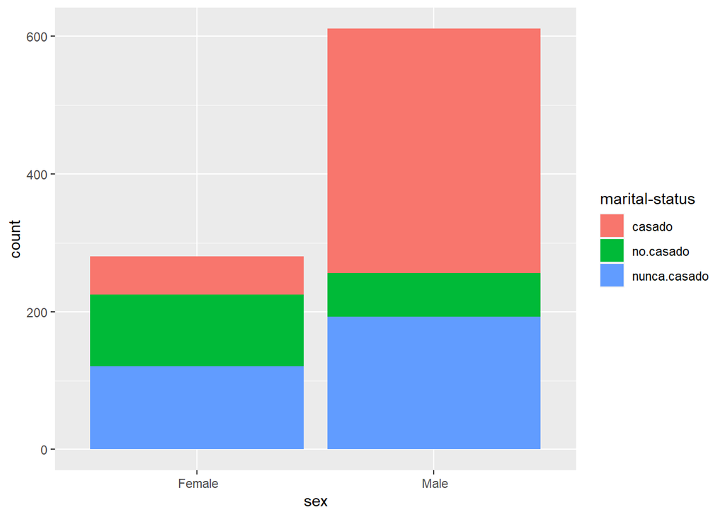

```r
ggplot(data=df1[1:filas,],aes(x=sex,fill=`marital-status`))+geom_bar()
```

### 4.2.6 Occupation

Vamos a categorizar la variable occupation

```r
unique(df1$occupation)
```

```
##  [1] " Handlers-cleaners" " Prof-specialty"    " Exec-managerial"
##  [4] " Other-service"     " Adm-clerical"      " Sales"
##  [7] " Craft-repair"      " Transport-moving"  " Farming-fishing"
## [10] " Machine-op-inspct" " Tech-support"      " ?"
## [13] " Protective-serv"   " Armed-Forces"      " Priv-house-serv"
```

Hay datos de origen desconocido. Vamos a ver la tabla de frecuencias.

```r
table(df1$occupation)
```

```
##
##                  ?       Adm-clerical       Armed-Forces
##               1456               3043                  8
##       Craft-repair    Exec-managerial    Farming-fishing
##               3253               3261                717
##  Handlers-cleaners  Machine-op-inspct      Other-service
##               1104               1667               2589
##    Priv-house-serv     Prof-specialty    Protective-serv
##                115               3311                542
##              Sales       Tech-support   Transport-moving
##               2941                740               1276
```

Hay 1456 profesiones de orgien desconocido. También vemos que hay 8 que pertenecen a las fuerzas armadas, que vamos a unir con los de origen desconocido.

```r
White_collar <- c(" Adm-clerical", " Exec-managerial", " Tech-support")
Desconocido <- c(" Armed-Forces", " Unknown")
Blue_collar <- c(" Craft-repair", " Farming-fishing", " Handlers-cleaners", " Machine-op-inspct", " Transport-moving")
Servicios <- c(" Other-service", " Priv-house-serv")
Profesional <- c(" Prof-specialty")
Ventas <- c(" Sales")
```

```r
ocupaciones <- function(ocupacion){
  if(ocupacion %in% White_collar){
    return("White_collar")
  }else if(ocupacion %in% Ventas){
    return("Sales")
  }else if(ocupacion %in% Blue_collar){
    return("Blue_collar")
  }else if(ocupacion %in% Servicios){
    return("Servicios")
  }else if(ocupacion %in% Profesional){
    return("Profesional")
  }else{return("Desconocido")}
}
```

```r
df1$occupation<- sapply(df1$occupation, ocupaciones)
```

```r
table(df1$occupation)
```

```
##
##  Blue_collar  Desconocido  Profesional        Sales    Servicios
##         8017         2006         3311         2941         2704
## White_collar
##         7044
```

Ya tenemos categorizada nuestra variable. Vamos a ver gráficamente la relación entre edad y la ocupación,

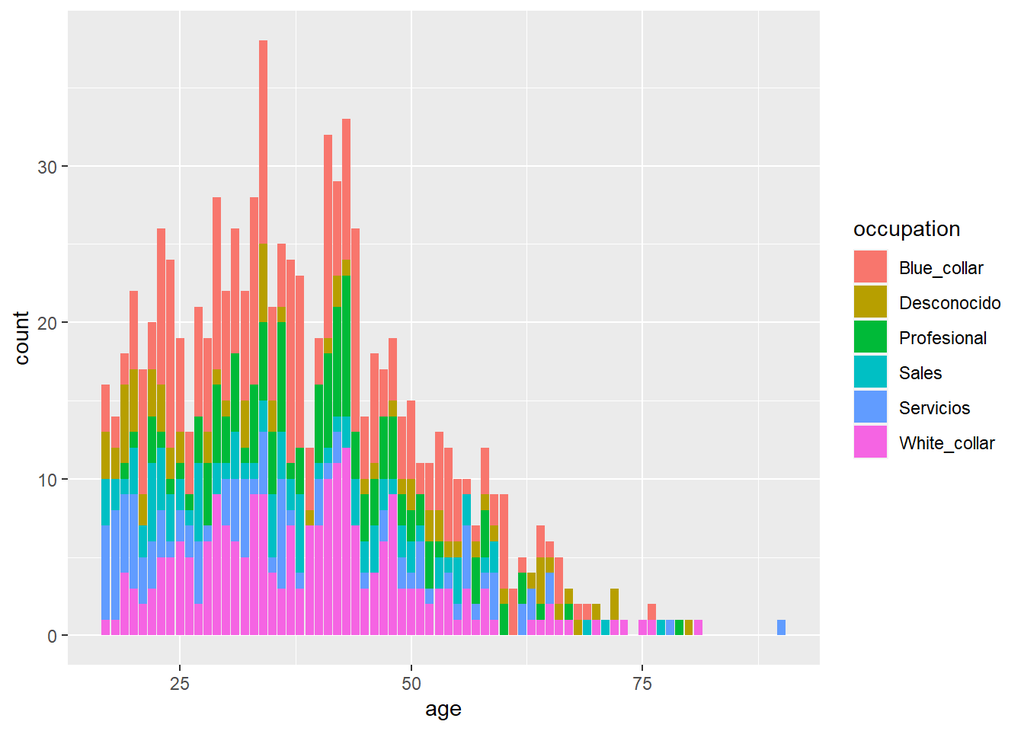

```r
ggplot(data=df1[1:filas,],aes(x=age,fill=occupation))+geom_bar()
```

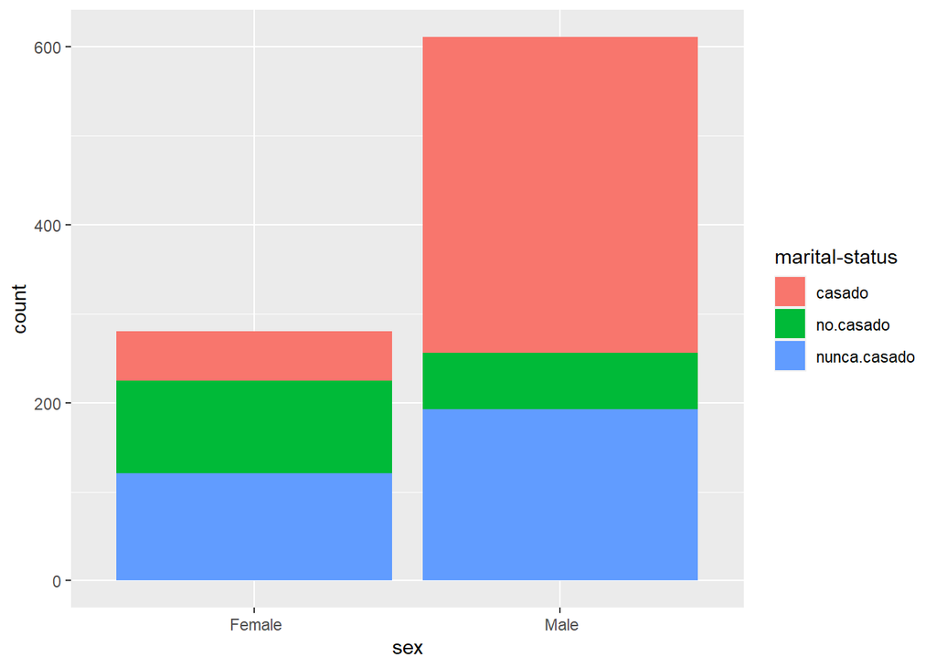

```r
ggplot(data=df1[1:filas,],aes(x=sex,fill=`marital-status`))+geom_bar()
```

Vamos a ver también la relación entre ocupación y workclass.

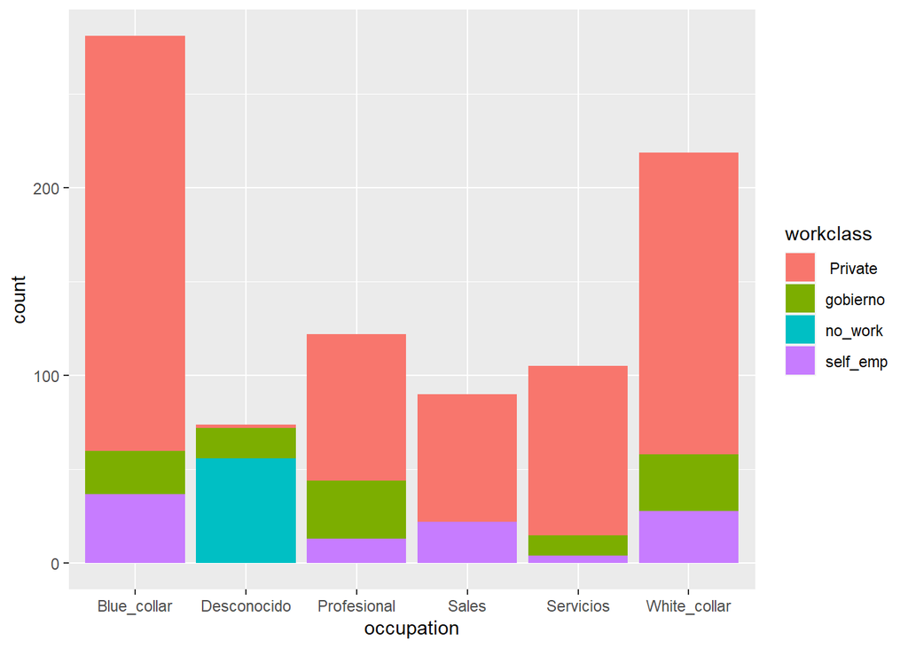

```r
ggplot(data=df1[1:filas,],aes(x=occupation,fill=workclass))+geom_bar()
```

Vemos que la mayoría de blue collar trabajan para la empresa privada, seguidos de autónomos y por último una pequeña cantidad trabaja para el gobierno. De origen desconocido la mayoría no trabajan, teniendo en cuenta que hemos incluido aquí una gran cantidad de datos de los que no sabíamos de dónde salían es importante ver que realmente es gente que en su mayoría no tiene trabajo. Con respecto a las ventas vemos que o son autónomos o trabajan en el sector privado, pero no trabajan para el gobierno ni están sin empleo. En el sector servicios hay una pequeña cantidad de trabajadores autónomos, algunos trabajan para el gobierno y la mayoría lo hacen en el sector privado. Y los white collars trabajan principalmente en el sector privado, y aparentemente la misma canditdad trabaja para el gobierno o es autonoma, pero tampoco están desempleados.

### 4.2.7 native country

Vamos a ver los paises y a categorizar la variable

```r
unique(df1$`native-country`)
```

```
##  [1] " United-States"              " Cuba"
##  [3] " Jamaica"                    " India"
##  [5] " ?"                          " Mexico"
##  [7] " South"                      " Puerto-Rico"
##  [9] " England"                    " Canada"
## [11] " Iran"                       " Philippines"
## [13] " Italy"                      " Poland"
## [15] " Columbia"                   " Cambodia"
## [17] " Thailand"                   " Germany"
## [19] " Ecuador"                    " Laos"
## [21] " Taiwan"                     " Haiti"
## [23] " Portugal"                   " Dominican-Republic"
## [25] " France"                     " El-Salvador"
## [27] " Guatemala"                  " China"
## [29] " Japan"                      " Yugoslavia"
## [31] " Peru"                       " Outlying-US(Guam-USVI-etc)"
## [33] " Greece"                     " Nicaragua"
## [35] " Honduras"                   " Vietnam"
## [37] " Trinadad&Tobago"            " Hong"
## [39] " Ireland"                    " Scotland"
## [41] " Hungary"                    " Holand-Netherlands"
```

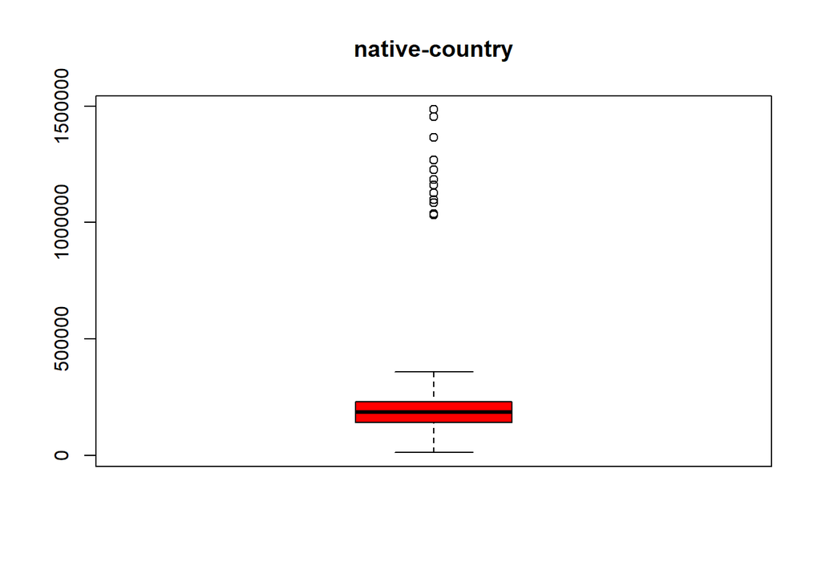

```r
boxplot(df1$fnlwgt,
        main = "native-country",
        boxwex = 0.5, col = "red")
```

```r
table(df1$`native-country`)
```

```
##
##                           ?                    Cambodia
##                         489                          16
##                      Canada                       China
##                          88                          59
##                    Columbia                        Cuba
##                          53                          92
##          Dominican-Republic                     Ecuador
##                          66                          28
##                 El-Salvador                     England
##                          75                          68
##                      France                     Germany
##                          22                         105
##                      Greece                   Guatemala
##                          26                          48
##                       Haiti          Holand-Netherlands
##                          43                           1
##                    Honduras                        Hong
##                          10                          20
##                     Hungary                       India
##                          12                          85
##                        Iran                     Ireland
##                          36                          20
##                       Italy                     Jamaica
##                          64                          75
##                       Japan                        Laos
##                          43                          15
##                      Mexico                   Nicaragua
##                         454                          26
##  Outlying-US(Guam-USVI-etc)                        Peru
##                          11                          24
##                 Philippines                      Poland
##                         143                          56
##                    Portugal                 Puerto-Rico
##                          24                         106
##                    Scotland                       South
##                           9                          69
##                      Taiwan                    Thailand
##                          47                          16
##             Trinadad&Tobago               United-States
##                          16                       23292
##                     Vietnam                  Yugoslavia
##                          57                          14
```

```r
Asia <- c(" Cambodia", " China", " Hong", " India", " Iran", " Japan", " Laos", " Philippines", " Taiwan", " Thailand", " Vietnam")
Nor_America <- c(" Canada", " United-States")
Sur_America <- c(" Columbia", " Cuba", " Dominican-Republic", " Ecuador", " El-Salvador", " Guatemala", " Haiti", " Honduras", " Jamaica", " Mexico", " Nicaragua", " Outlying-US(Guam-USVI-etc", " Peru", " Puerto-Rico", " Trinidad&Tobago")
Europa <-c(" England", " France", " Germany", " Greece", " Holand-Netherlands", " Hungary", " Ireland", " Italy", " Poland", " Portugal", " Scotland", " Yugoslavia")
Otros <- c(" South", " ?")
```

```r
continente <-function(pais){
    if(pais %in% Asia){
      return("Asia")
    }else if(pais %in% Nor_America){
      return("Nor_America")
    }else if(pais %in% Sur_America){
      return("Sur_America")
    }else if(pais %in% Europa){
      return("Europa")
    }else{
      return("Otros")
    }
}
```

```r
df1$`native-country`<- sapply(df1$`native-country`, continente)
```

```r
table(df1$`native-country`)
```

```
##
##        Asia      Europa Nor_America       Otros Sur_America
##         537         421       23380         585        1100
```

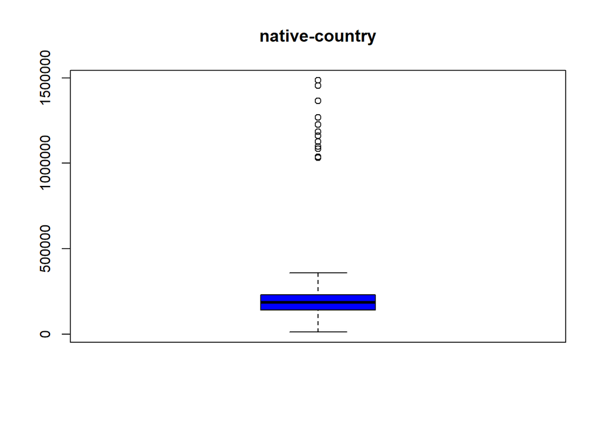

```r
boxplot(df1$fnlwgt,
        main = "native-country",
        boxwex = 0.5, col = "blue")
```

```r
prop.table(table(df1$`native-country`))
```

```
##
##        Asia      Europa Nor_America       Otros Sur_America
##  0.02063559  0.01617800  0.89843600  0.02248011  0.04227030
```

### 4.2.8 income

La variable ingresos Income, solo diferencia entre menor o igual de 50k, no sabemos cuál es la moneda de referencia, y más de 50k. Vemos que el porcentaje de menor o igual de 50k es superior al de observaciones que cobran más de esa cantidad:

```r
round(prop.table(table(df1$income))*100, 2)
```

```
##
##  <=50K   >50K
##  75.56  24.44
```

Vamos a ver por continentes, cuáles tienes mayores ingresos.

```r
table(df1$`native-country`, df1$income)
```

```
##
##                <=50K  >50K
##   Asia           365   172
##   Europa         303   118
##   Nor_America  17532  5848
##   Otros          447   138
##   Sur_America   1015    85
```

Y en porcentajes

```r
A <- round(prop.table(table(df1$`native-country`, df1$income))*100,2)
A
```

```
##
##                <=50K  >50K
##   Asia          1.40  0.66
##   Europa        1.16  0.45
##   Nor_America  67.37 22.47
##   Otros         1.72  0.53
##   Sur_America   3.90  0.33
```

Vamos a verlo gráficamente.

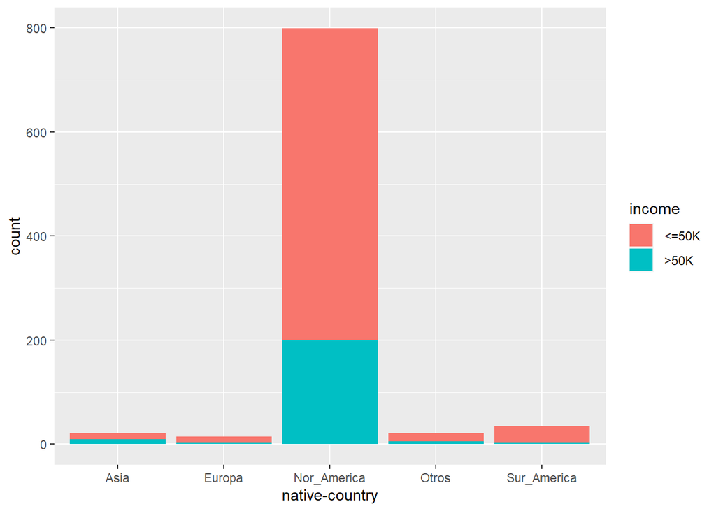

```r
ggplot(data=df1[1:filas,],aes(x=`native-country`, fill= income ))+geom_bar()
```

Vemos que como la mayoría de datos están recogidos en norte América, es complicado ver el resto de datos.